# Data Minning 1

Sayeli Chakraborty

August 26, 2019

Library

```r
library(psych)
library(caret)
library(glmnet)
dataset = read.csv('hitllers.csv')
head(dataset)
```

```
##        X AtBat Hits HmRun Runs RBI Walks Years CAtBat CHits CHmRun CRuns
## 1 #NAME?   293   66     1   30  29    14     1    293    66      1    30
## 2 #NAME?   315   81     7   24  38    39    14   3449   835     69   321
## 3 #NAME?   479  130    18   66  72    76     3   1624   457     63   224
## 4 #NAME?   496  141    20   65  78    37    11   5628  1575    225   828
## 5 #NAME?   321   87    10   39  42    30     2    396   101     12    48
## 6 #NAME?   594  169     4   74  51    35    11   4408  1133     19   501
##   CRBI CWalks League Division PutOuts Assists Errors Salary NewLeague
## 1   29     14      A        E     446      33     20     NA         A
## 2  414    375      N        W     632      43     10  475.0         N
## 3  266    263      A        W     880      82     14  480.0         A
## 4  838    354      N        E     200      11      3  500.0         N
## 5   46     33      N        E     805      40      4   91.5         N
## 6  336    194      A        W     282     421     25  750.0         A
```

# Sum of Missing Value

```r
sum(is.na(dataset))
```

```
## [1] 59
```

# plot the missing Values

```r
library(VIM)
```

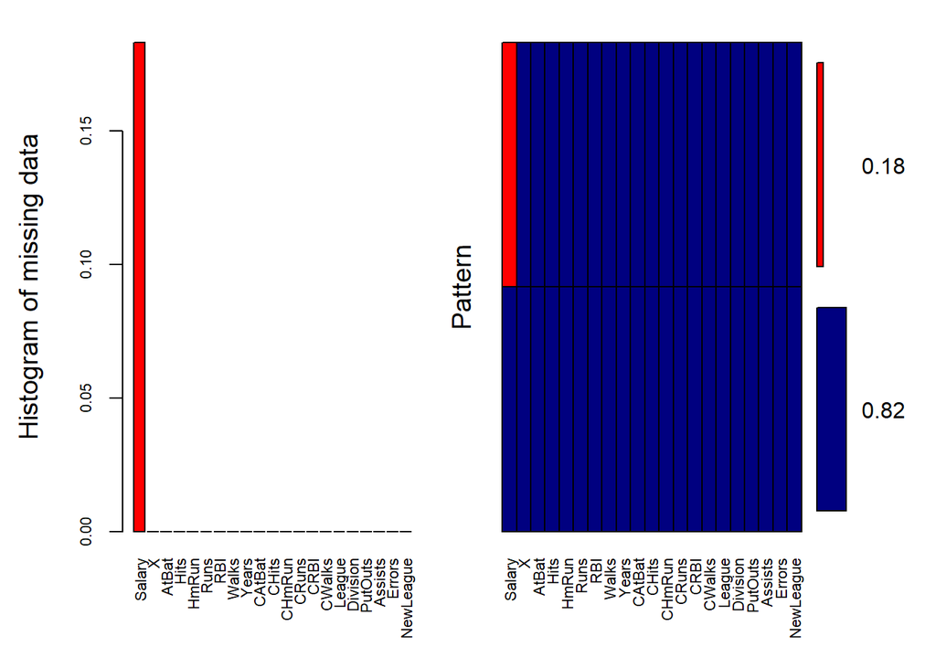

```
##
##  Variables sorted by number of missings:
##   Variable     Count
##     Salary 0.1832298
##          X 0.0000000
##      AtBat 0.0000000
##       Hits 0.0000000
##      HmRun 0.0000000
##       Runs 0.0000000
##        RBI 0.0000000
##      Walks 0.0000000
##      Years 0.0000000
##     CAtBat 0.0000000
##      CHits 0.0000000
##     CHmRun 0.0000000
##      CRuns 0.0000000
##       CRBI 0.0000000
##     CWalks 0.0000000
##     League 0.0000000
##   Division 0.0000000
##    PutOuts 0.0000000
##    Assists 0.0000000
##     Errors 0.0000000
##  NewLeague 0.0000000
```

```r
aggr_plot <- aggr(dataset, col=c('navyblue','red'), numbers=TRUE, sortVars=TRUE, labels=names(data), cex.axis=.7, gap=3, ylab=c("Histogram of missing data","Pattern"))
```

# Removing the not required Variable

```r
dataset1 <- dataset[, c(2:14,17,18,19,20)]
```

# Feature Scaling

```r
dataset1[-17] <- scale(dataset1[-17])
head(dataset1)
```

```
##        AtBat       Hits      HmRun       Runs        RBI       Walks
## 1 -0.5731794 -0.7539563 -1.1218446 -0.8034838 -0.7271765 -1.14339215
## 2 -0.4297681 -0.4310614 -0.4329051 -1.0340393 -0.3832304  0.01191183
## 3  0.6392975  0.6237287  0.8301507  0.5798496  0.9161213  1.72176171
## 4  0.7501153  0.8605183  1.0597972  0.5414237  1.1454187 -0.08051249
## 5 -0.3906560 -0.3019034 -0.0884353 -0.4576504 -0.2303655 -0.40399760
## 6  1.3889473  1.4632555 -0.7773748  0.8872570  0.1135805 -0.17293681
##        Years     CAtBat      CHits       CHmRun      CRuns        CRBI
## 1 -1.3081578 -1.0135433 -0.9955671 -0.793947035 -0.9841043 -0.90366232
## 2  1.3308535  0.3443399  0.1794247 -0.005688022 -0.1131229  0.25173184
## 3 -0.9021560 -0.4408746 -0.3981395 -0.075240288 -0.4034500 -0.19241968
## 4  0.7218509  1.2818644  1.3101061  1.802670892  1.4043601  1.52416593
## 5 -1.1051569 -0.9692271 -0.9420889 -0.666434548 -0.9302291 -0.85264492
## 6  0.7218509  0.7569539  0.6347532 -0.585290238  0.4256284  0.01765198
##        CWalks     PutOuts    Assists     Errors Salary
## 1 -0.92204335  0.55952807 -0.5400834  1.8779763     NA
## 2  0.42972251  1.22214632 -0.4670133  0.3077131  475.0
## 3  0.01033809  2.10563732 -0.1820399  0.9358184  480.0
## 4  0.35108793 -0.31683800 -0.7008376 -0.7914712  500.0
## 5 -0.85089778  1.83845255 -0.4889343 -0.6344449   91.5
## 6 -0.24803267 -0.02471597  2.2950366  2.6631079  750.0
```

Now to run the models and to find the NA Values. We will divide the dataset into taining and test set. Training set will not contain NA Value.

```r
test_set <- dataset1[is.na(dataset1$Salary),]
head(test_set)
```

```
##         AtBat        Hits      HmRun       Runs        RBI       Walks
## 1  -0.5731794 -0.75395630 -1.1218446 -0.8034838 -0.7271765 -1.14339215
## 16 -1.2902356 -1.33516715 -0.8921981 -1.1877430 -1.2622037 -1.28202862
## 19  0.1699516  0.06404417 -0.5477283  0.2340163 -0.1921493  1.21342796
## 23 -2.3397452 -1.95943066 -1.1218446 -1.8025579 -1.7590146 -1.74415021
## 31 -0.4428055 -0.36648239 -0.2032586 -0.3423726 -0.6889602  0.01191183
## 33  0.8870079  0.86051830  1.8635600  0.7335533  1.4893647  0.61266990
##         Years     CAtBat      CHits     CHmRun      CRuns       CRBI
## 1  -1.3081578 -1.0135433 -0.9955671 -0.7939470 -0.9841043 -0.9036623
## 16 -0.9021560 -1.0531267 -1.0322379 -0.7707629 -1.0140349 -0.9426756
## 19  0.9248518  1.1119139  1.1618951  0.3536654  0.8506434  0.9839816
## 23 -0.2931534 -1.1034665 -1.0566850 -0.7823550 -1.0469586 -0.9636828
## 31  1.9398561  1.8248456  1.7043166  1.7910788  2.0179380  1.6021925
## 33  0.3158492  0.3968309  0.4223684  1.6867504  0.5573232  0.9659755
##        CWalks    PutOuts     Assists       Errors Salary
## 1  -0.9220433  0.5595281 -0.54008337  1.877976285     NA
## 16 -0.9332769 -0.6089600 -0.78121472 -1.262550144     NA
## 19  1.4706946  2.2196362 -0.13819780  0.150686749     NA
## 23 -0.9632329  1.8633898 -0.16742585  0.464739392     NA
## 31  3.0958092 -0.5768978  0.83363457 -0.163365893     NA
## 33  0.2874314  3.8797443 -0.03589966 -0.006339572     NA
```

```r
training_set <- dataset1[!is.na(dataset1$Salary),]
```

# Custom Control Parameters

```r
cust<-trainControl(method = 'repeatedcv',number = 10,repeats = 5)
```

# LINER MODEL

```r
set.seed(224)
m<-train(Salary~.,
         training_set,
         method='lm',
         trControl=cust)
m
```

```
## Linear Regression
##
## 263 samples
##  16 predictor
##
## No pre-processing
## Resampling: Cross-Validated (10 fold, repeated 5 times)
## Summary of sample sizes: 237, 236, 236, 235, 238, 238, ...
## Resampling results:
##
##   RMSE      Rsquared   MAE
##   340.6112  0.4508353  238.0401
##
## Tuning parameter 'intercept' was held constant at a value of TRUE
```

```r
summary(m)
```

```
##
## Call:
## lm(formula = .outcome ~ ., data = dat)
##
## Residuals:
##     Min      1Q  Median      3Q     Max
## -982.81 -187.84  -35.66  130.61 1947.43
##
## Coefficients:
##              Estimate Std. Error t value Pr(>|t|)
## (Intercept)  517.6429    20.0481  25.820  < 2e-16 ***
## AtBat       -337.9545    97.5739  -3.464 0.000629 ***
## Hits         363.6366   111.5835   3.259 0.001276 **
## HmRun         18.8424    54.3111   0.347 0.728937
## Runs         -54.6393    78.2932  -0.698 0.485911
## RBI           -0.5996    68.3043  -0.009 0.993003
## Walks        133.1048    39.8225   3.342 0.000960 ***
## Years        -12.7702    61.3495  -0.208 0.835280
## CAtBat      -409.7019   317.6434  -1.290 0.198325
## CHits         45.6571   444.2191   0.103 0.918221
## CHmRun       -20.1076   141.0979  -0.143 0.886795
## CRuns        537.9272   251.1219   2.142 0.033168 *
## CRBI         267.0514   233.2549   1.145 0.253367
## CWalks      -212.0285    88.7774  -2.388 0.017681 *
## PutOuts       82.6881    21.9805   3.762 0.000211 ***
## Assists       52.5516    30.6321   1.716 0.087499 .
## Errors       -18.3327    28.1531  -0.651 0.515539
## ---
## Signif. codes:  0 '***' 0.001 '**' 0.01 '*' 0.05 '.' 0.1 ' ' 1
##
## Residual standard error: 319.9 on 246 degrees of freedom
## Multiple R-squared:  0.5279, Adjusted R-squared:  0.4972
## F-statistic: 17.19 on 16 and 246 DF,  p-value: < 2.2e-16
```

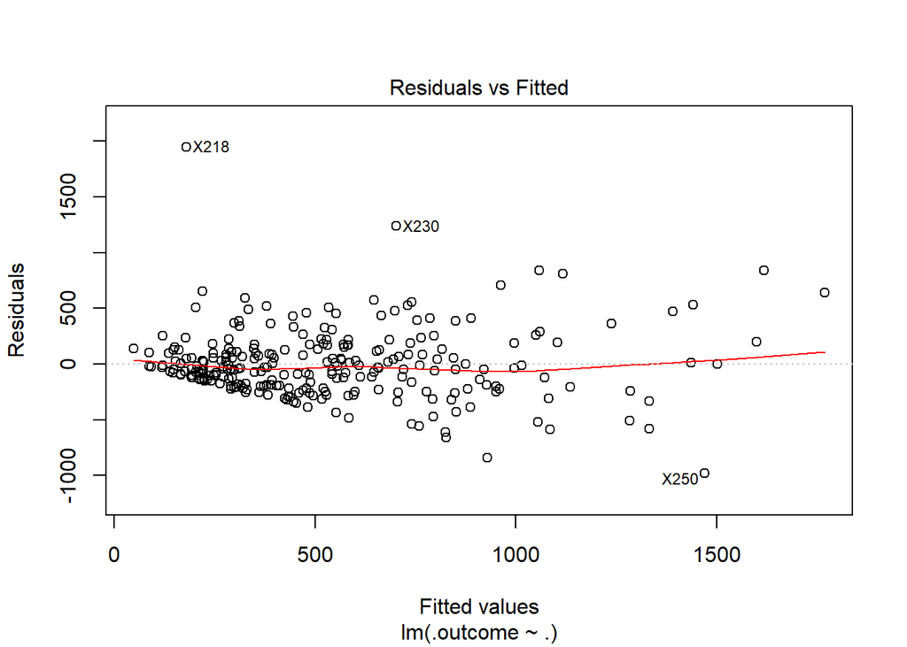

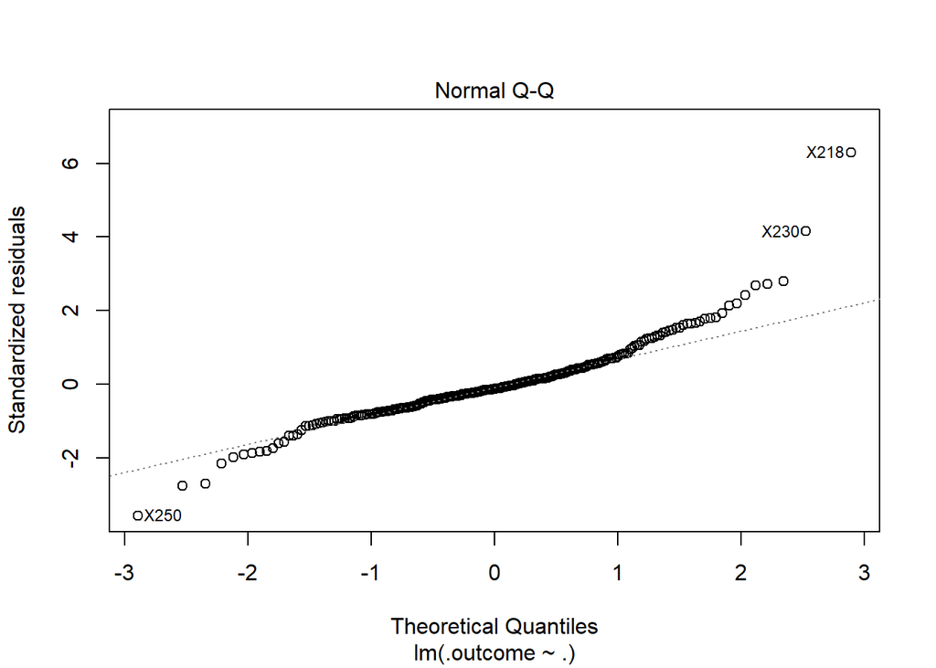

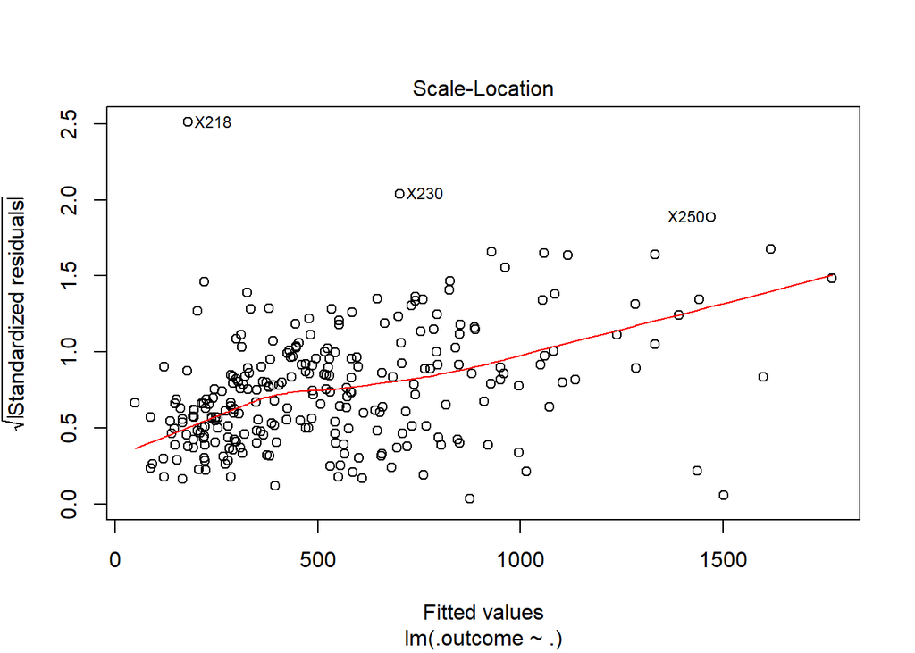

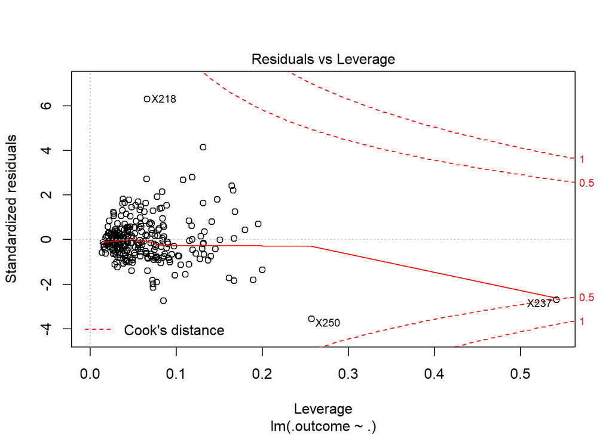

```r
plot(m$finalModel)
```

# RIDGE MODEL

```r
r<-train(Salary~.,
         training_set,
         method='glmnet',
         tuneGrid=expand.grid(alpha=0,lambda=seq(0.001,1,length=10)),
         trControl=cust)
r
```

```
## glmnet
##
## 263 samples
##  16 predictor
##
## No pre-processing
## Resampling: Cross-Validated (10 fold, repeated 5 times)
## Summary of sample sizes: 237, 236, 235, 237, 238, 238, ...
## Resampling results across tuning parameters:
##
##   lambda  RMSE      Rsquared  MAE
##   0.001   334.2974  0.481294  233.5665
##   0.112   334.2974  0.481294  233.5665
##   0.223   334.2974  0.481294  233.5665
##   0.334   334.2974  0.481294  233.5665
##   0.445   334.2974  0.481294  233.5665
##   0.556   334.2974  0.481294  233.5665
##   0.667   334.2974  0.481294  233.5665
##   0.778   334.2974  0.481294  233.5665
##   0.889   334.2974  0.481294  233.5665
##   1.000   334.2974  0.481294  233.5665
##
## Tuning parameter 'alpha' was held constant at a value of 0
## RMSE was used to select the optimal model using the smallest value.
## The final values used for the model were alpha = 0 and lambda = 1.
```

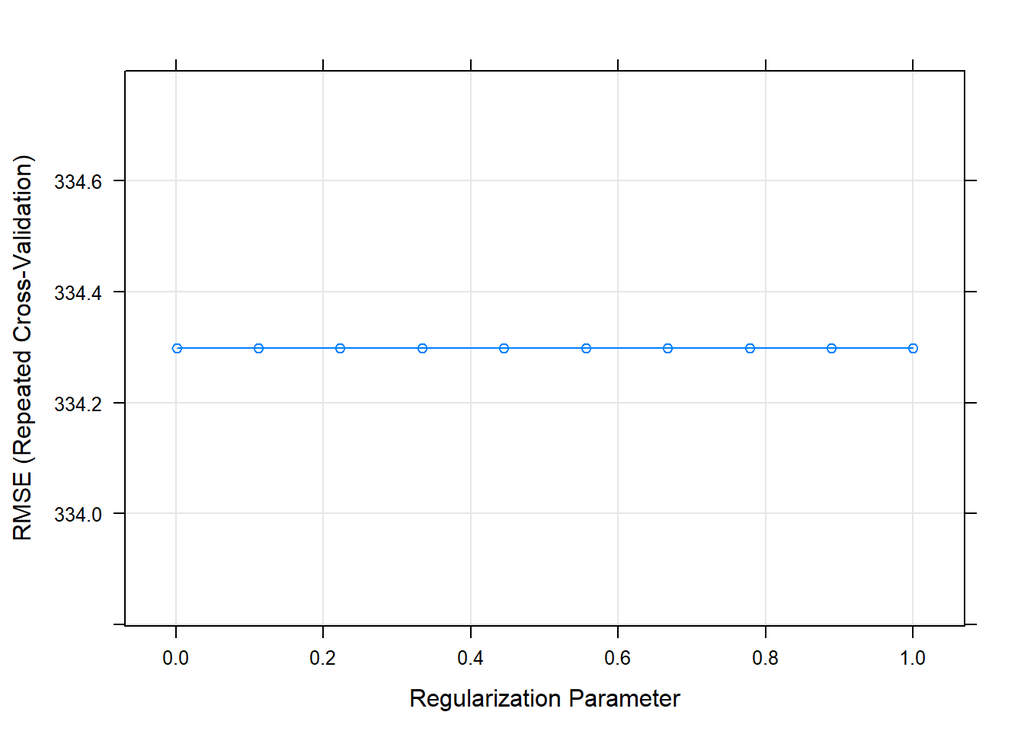

```r
plot(r)
```

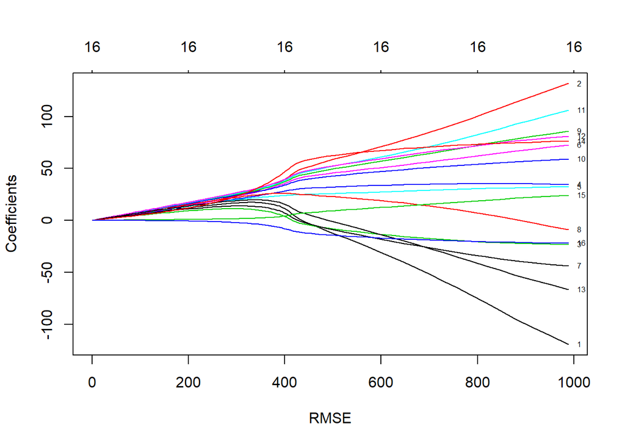

```r
plot(r$finalModel,xlab='RMSE',label = T)
```

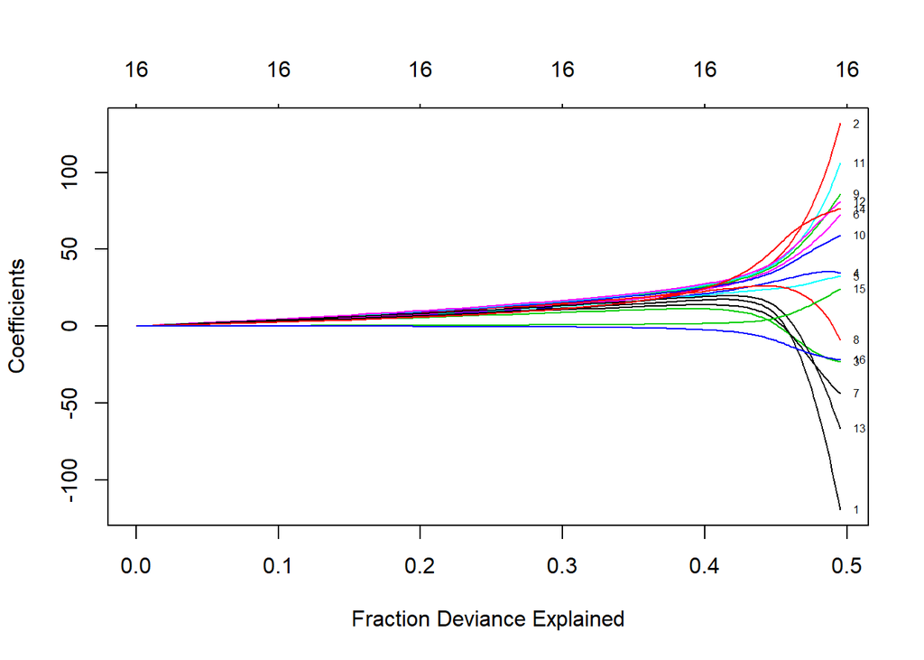

```r
plot(r$finalModel,xvar='dev',label = T)
```

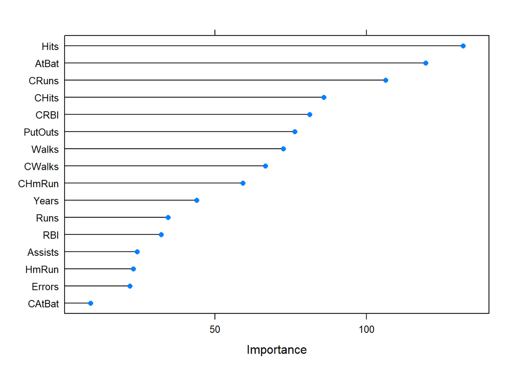

```r
plot(varImp(r,scale = FALSE))
```

So here we can see for all values of lamda RMSE is the same & Rsquared is the same. In Ridge anyways alpha remains zero. So when the lamda is 1 (Strenght of the penalty over Coefficients) coefficeints can be best expalined.

So Here from plot we can see that in the Right side is RMSE based on cross validation. Here Error is same throughout till lamda is 1. So the best value which we get for lamda is 1.

After Plotting FinalModel: Intially all the coefficients are zero. When we started to relax lamda cofficient of the variables stared to grow. At the top we have all 16 independent variables

Fraction Devience Explained Graph: 40% of the variablity is explained properly with slight growth in the coefficient and it grows gradually goes upto 50% after that the coffifient started jump.

# LASSO MODEL

```r
l<-train(Salary~.,
         training_set,
         method='glmnet',
         tuneGrid=expand.grid(alpha=1,lambda=seq(0.001,1,length=10)),
         trControl=cust)
l
```

```
## glmnet
##
## 263 samples
##  16 predictor
##
## No pre-processing
## Resampling: Cross-Validated (10 fold, repeated 5 times)
## Summary of sample sizes: 237, 235, 236, 238, 237, 238, ...
## Resampling results across tuning parameters:
##
##   lambda  RMSE      Rsquared   MAE
##   0.001   335.3219  0.4700715  236.6451
##   0.112   335.0353  0.4704850  236.5157
##   0.223   334.4035  0.4719016  236.0853
##   0.334   333.8951  0.4732025  235.7049
##   0.445   333.4960  0.4742894  235.3639
##   0.556   333.1842  0.4752075  235.0642
##   0.667   332.9024  0.4760694  234.7829
##   0.778   332.6601  0.4768630  234.5261
##   0.889   332.4726  0.4775333  234.3179
##   1.000   332.3289  0.4781028  234.1474
##
## Tuning parameter 'alpha' was held constant at a value of 1
## RMSE was used to select the optimal model using the smallest value.
## The final values used for the model were alpha = 1 and lambda = 1.
```

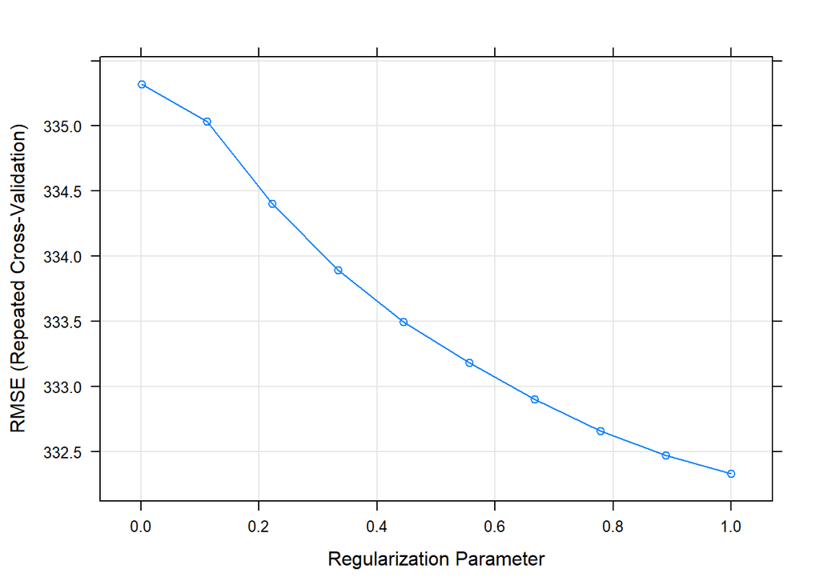

```r
plot(l)
```

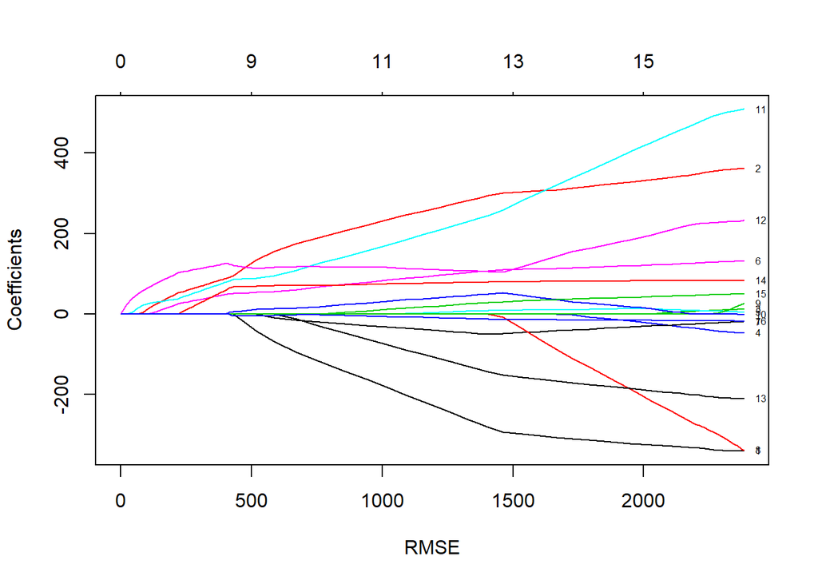

```r
plot(l$finalModel,xlab='RMSE',label = T)
```

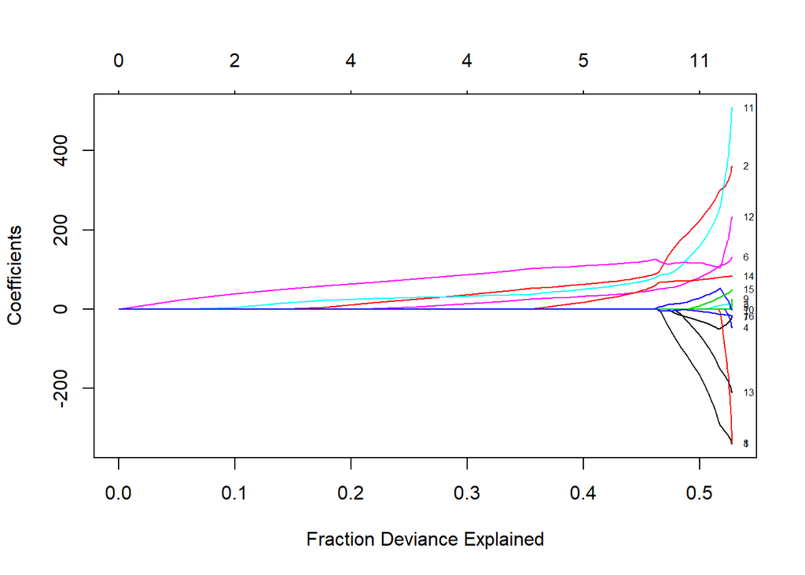

```r
plot(l$finalModel,xvar='dev',label = T)
```

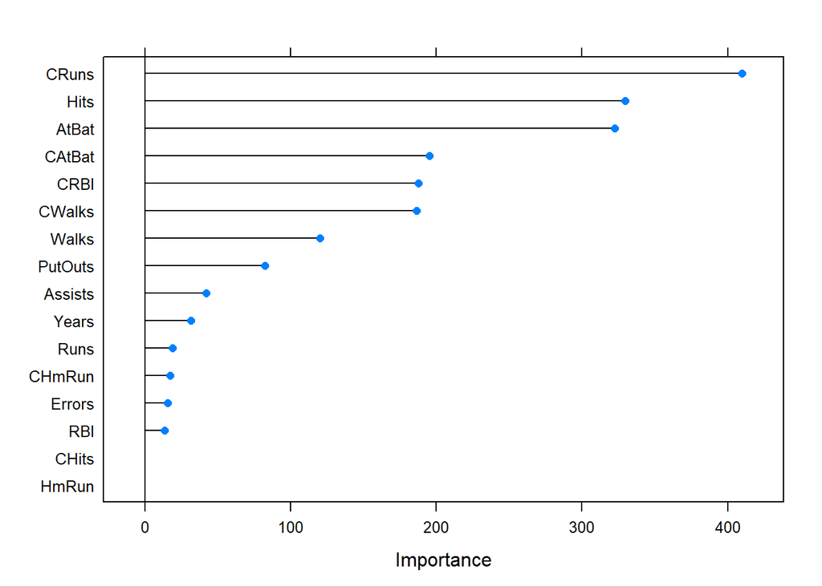

```r
plot(varImp(l,scale = FALSE))
```

Fraction Devience Explained Graph: 40% of the variablity is explained properly with slight growth in the coefficient by two variables and it grows gradually goes upto 55% after that the coffifient started jump. After 55% area the model is overfitted.

In Lasso the model is better now as we can see the variables which are important given on the top and few are removed due to multicolliniarity.